# Final Prject Preliminary EDA

Jiarui Fan

```r
# clean up R environment
rm (list = ls())
# load some packages
library(readr)
library(tidyverse)
library(DataComputing)
library(ggplot2)
library(tidyr)
library(lubridate)
```

## 1: Which is the Most Popular Ramen Product?

### Data source

```r
RamenFile<- file.choose()
```

```r
RamenData<-
  data.table::fread(RamenFile)%>%
  as.data.frame()
```

```r
View(RamenData)
str(RamenData)
```

```
'data.frame':   2580 obs. of  7 variables:
 $ Review #: int  2580 2579 2578 2577 2576 2575 2574 2573 2572 2571 ...
 $ Brand   : chr  "New Touch" "Just Way" "Nissin" "Wei Lih" ...
 $ Variety : chr  "T's Restaurant Tantanmen" "Noodles Spicy Hot Sesame Spicy Hot Sesame Guan-miao Noodles" "Cup Noodles Chicken Vegetable" "GGE Ramen Snack Tomato Flavor" ...
 $ Style   : chr  "Cup" "Pack" "Cup" "Pack" ...
 $ Country : chr  "Japan" "Taiwan" "USA" "Taiwan" ...
 $ Stars   : chr  "3.75" "1" "2.25" "2.75" ...
 $ Top Ten : chr  "" "" "" "" ...
```

##### Where

[Ramen Ratings | Kaggle](https://www.kaggle.com/residentmario/ramen-ratings) This data set is found in Kaggle.

##### Who & When

The dataset owner is Aleksey Bilogur, he collected the data and maintained it. The last update is 3 years ago. However, Mr.Bilogur states that“This dataset is republished as-is from the original BIG LIST on https://www.theramenrater.com/.”

##### Why

According to the data description, the inspiration is from these questions:

- What ingredients or flavors are most commonly advertised on ramen package labels?
- How do ramen ratings compare against ratings for other food products (like, say, wine)?
- How is ramen manufacturing internationally distributed?

##### What does a case represent? & How may total cases are available?

One case is a variety of Ramen with a certain brand, certain number of reviews, its style of packaging(Cup/Bowl/Tray), country, star rating(5-point scale), and if it went on Top 10.

```r
RamenData%>%
  nrow()
```

```
[1] 2580
```

There are 2580 cases available.

##### What variables will be using

Since there are only 7 attributes, I am going to use all of them if possible.

### Exploration

##### Informative statistics

- How many distinct brand are there in the data set

```r
RamenData%>%
  group_by(n_distinct(Brand))%>%
  summarise()
```

| n_distinct(Brand) |
| --- |
| 355 |

- How many Ramen scored 4.5 +

```r
RamenData%>%
  select(Brand, Stars, Variety, Country)%>%
  group_by(Brand)%>%
  filter(Stars>=4.5, Stars != "Unrated")%>%
  arrange(desc(Stars))
```

| Brand | Stars | Variety | Country |
| --- | --- | --- | --- |
| Mr. Lee's Noodles | 5.00 | Hong Kong Street Beef | UK |
| Nissin | 5.00 | Kimchi Chikin Ramen Donburi | Japan |
| Nissin | 5.00 | Mennippon Oumi Chanpon | Japan |
| MyKuali | 5.00 | Penang Red Tom Yum Goong Noodle Authentic Taste | Malaysia |
| Nissin | 5.00 | Cup Noodle Big Cheese Mexican Chilli | Japan |
| MyKuali | 5.00 | Penang White curry Noodle Authentic Taste | Malaysia |
| MyOri | 5.00 | Malaysia Penang Green Curry Vermicelli (New Package) | Malaysia |
| Happy Cook | 5.0 | Sichuan Spicy Flavor | Taiwan |
| Nissin | 5.0 | Gyorai Inaniwa Chuka Soba | Japan |
| Maruchan | 5.0 | Instant Lunch Chipotle Chicken Flavor Ramen Noodle Soup | USA |

[output cut: 575 more lines]

- How many distinct countries are there?

```r
RamenData%>%
  group_by(n_distinct(Country))%>%
  summarise()
```

| n_distinct(Country) |
| --- |
| 38 |

- Ramen with the most reviews.

```r
RamenData%>%
  arrange(desc(`Review #`))
```

| Review # | Brand | Variety | Style | Country | Stars | Top Ten |
| --- | --- | --- | --- | --- | --- | --- |
| 2580 | New Touch | T's Restaurant Tantanmen | Cup | Japan | 3.75 |  |
| 2579 | Just Way | Noodles Spicy Hot Sesame Spicy Hot Sesame Guan-miao Noodles | Pack | Taiwan | 1 |  |
| 2578 | Nissin | Cup Noodles Chicken Vegetable | Cup | USA | 2.25 |  |
| 2577 | Wei Lih | GGE Ramen Snack Tomato Flavor | Pack | Taiwan | 2.75 |  |
| 2576 | Ching's Secret | Singapore Curry | Pack | India | 3.75 |  |
| 2575 | Samyang Foods | Kimchi song Song Ramen | Pack | South Korea | 4.75 |  |
| 2574 | Acecook | Spice Deli Tantan Men With Cilantro | Cup | Japan | 4 |  |
| 2573 | Ikeda Shoku | Nabeyaki Kitsune Udon | Tray | Japan | 3.75 |  |
| 2572 | Ripe'n'Dry | Hokkaido Soy Sauce Ramen | Pack | Japan | 0.25 |  |
| 2571 | KOKA | The Original Spicy Stir-Fried Noodles | Pack | Singapore | 2.5 |  |

[output cut: 990 more lines]

##### Informative plots

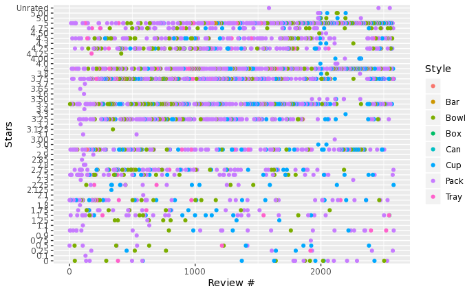

```r
RamenData%>%
  ggplot(aes(x = `Review #`, y = Stars))+geom_point(aes(color=Style))
```

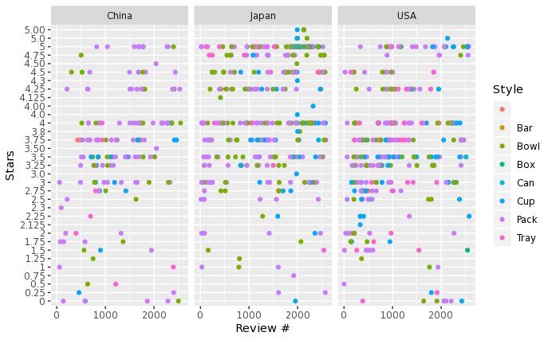

```r
ThreeCountry<-
  RamenData%>%
  filter(Country=="China"| Country=="USA"| Country=="Japan")
ThreeCountry%>%
  ggplot(aes(x=`Review #`, y = Stars))+geom_point(aes(color=Style))+facet_wrap(~Country)
```

## 2: Which is the most popular video game?

### Data source

```r
GameFile<- file.choose()
```

```r
GameData<-
  data.table::fread(GameFile)%>%
  as.data.frame()
```

```r
View(GameData)
str(GameData)
```

```
'data.frame':   16719 obs. of  16 variables:
 $ Name           : chr  "Wii Sports" "Super Mario Bros." "Mario Kart Wii" "Wii Sports Resort" ...
 $ Platform       : chr  "Wii" "NES" "Wii" "Wii" ...
 $ Year_of_Release: chr  "2006" "1985" "2008" "2009" ...
 $ Genre          : chr  "Sports" "Platform" "Racing" "Sports" ...
 $ Publisher      : chr  "Nintendo" "Nintendo" "Nintendo" "Nintendo" ...
 $ NA_Sales       : num  41.4 29.1 15.7 15.6 11.3 ...
 $ EU_Sales       : num  28.96 3.58 12.76 10.93 8.89 ...
 $ JP_Sales       : num  3.77 6.81 3.79 3.28 10.22 ...
 $ Other_Sales    : num  8.45 0.77 3.29 2.95 1 0.58 2.88 2.84 2.24 0.47 ...
 $ Global_Sales   : num  82.5 40.2 35.5 32.8 31.4 ...
 $ Critic_Score   : int  76 NA 82 80 NA NA 89 58 87 NA ...
 $ Critic_Count   : int  51 NA 73 73 NA NA 65 41 80 NA ...
 $ User_Score     : chr  "8" "" "8.3" "8" ...
 $ User_Count     : int  322 NA 709 192 NA NA 431 129 594 NA ...
 $ Developer      : chr  "Nintendo" "" "Nintendo" "Nintendo" ...
 $ Rating         : chr  "E" "" "E" "E" ...
```

##### Where

[Video Games Sales with Ratings | Kaggle](https://www.kaggle.com/rush4ratio/video-game-sales-with-ratings) This data set is found in Kaggle.

##### Who & When & Why

This dataset is collected and maintained by Rush Kirubi, and it was updated 4 years ago. According to the data description, this dataset was “Motivated by Gregory Smith’s web scrape of VGChartz Video Games Sales, this data set simply extends the number of variables with another web scrape from Metacritic.”

##### What does a case represent? & How may total cases are available?

A case in this dataset represents a type of video game with its information like platform, genre, publisher… and with its sales in million of units in different areas(North America, European Union, Japan, total sales in the world, etc) also with its scores, counts, and ratings.

```r
GameData%>%
  nrow()
```

```
[1] 16719
```

There are 16719 video games in the dataset.

##### What variables will be using

I will focus on: * Name * Platform * Year_of_Release * Genre * NA_Sales * EU_Sales * JP_Sales * Other_Sales * Global_Sales * User_Score

### Exploration

##### Informative statisstics

- How many distinct platforms are there?

```r
GameData%>%
  group_by(n_distinct(Platform))%>%
  summarise()
```

| n_distinct(Platform) |
| --- |
| 31 |

- How many distinct publishers are there?

```r
GameData%>%
  group_by(n_distinct(Publisher))%>%
  summarise()
```

| n_distinct(Publisher) |
| --- |
| 581 |

- How many distinct genres are there?

```r
GameData%>%
  distinct(Genre)
```

| Genre |
| --- |
| Sports |
| Platform |
| Racing |
| Role-Playing |
| Puzzle |
| Misc |
| Shooter |
| Simulation |
| Action |
| Fighting |

[output cut: 3 more lines]

- Video games which scored 9 +

```r
GameData%>%
  select(Name, User_Score, Genre, Publisher)%>%
  filter(User_Score >= 9, User_Score != "tbd")%>%
  arrange(desc(User_Score))
```

| Name | User_Score | Genre | Publisher |
| --- | --- | --- | --- |
| Breath of Fire III | 9.7 | Role-Playing | Capcom |
| Harvest Moon: Friends of Mineral Town | 9.6 | Simulation | Ubisoft |
| Boktai: The Sun is in Your Hand | 9.6 | Role-Playing | Konami Digital Entertainment |
| Golden Sun: The Lost Age | 9.5 | Role-Playing | Nintendo |
| MLB SlugFest Loaded | 9.5 | Sports | Midway Games |
| Cory in the House | 9.5 | Action | Disney Interactive Studios |
| Super Puzzle Fighter II | 9.5 | Puzzle | Capcom |
| Wade Hixton's Counter Punch | 9.5 | Sports | Destination Software, Inc |
| Karnaaj Rally | 9.5 | Racing | Jaleco |
| Metal Gear Solid | 9.4 | Action | Konami Digital Entertainment |

[output cut: 294 more lines]

- Popular genre rank

```r
GameData%>%
  group_by(Genre)%>%
  summarise(total = n())%>%
  arrange(desc(total))
```

| Genre | total |
| --- | --- |
| Action | 3370 |
| Sports | 2348 |
| Misc | 1750 |
| Role-Playing | 1500 |
| Shooter | 1323 |
| Adventure | 1303 |
| Racing | 1249 |
| Platform | 888 |
| Simulation | 874 |
| Fighting | 849 |

[output cut: 3 more lines]

##### Informative plots

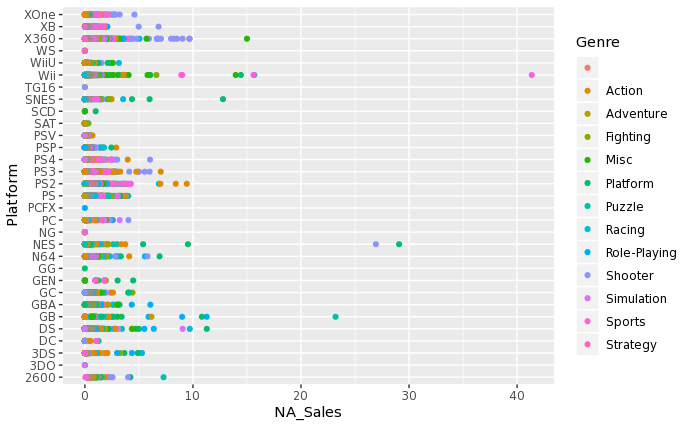

```r
GameData%>%
  ggplot(aes(x=NA_Sales, y = Platform))+geom_point(aes(color=Genre))
```

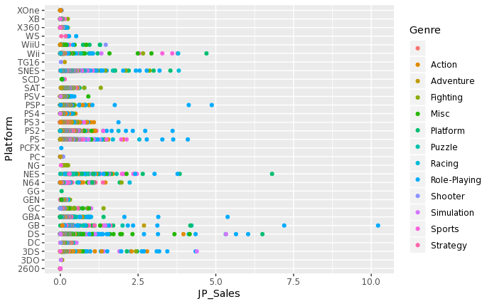

```r
GameData%>%
  ggplot(aes(x=JP_Sales, y = Platform))+geom_point(aes(color=Genre))
```

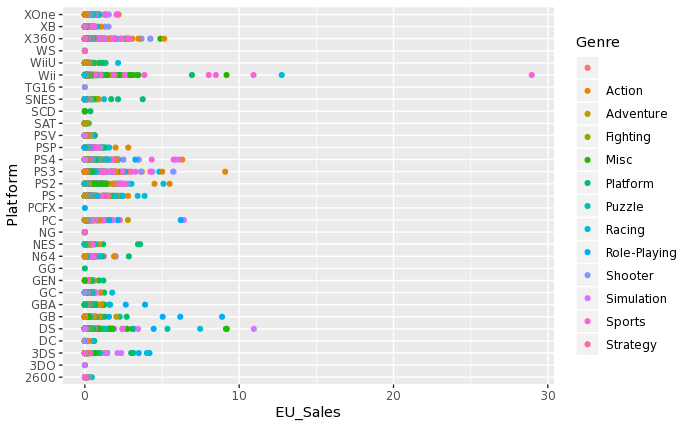

```r
GameData%>%
  ggplot(aes(x=EU_Sales, y = Platform))+geom_point(aes(color=Genre))
```

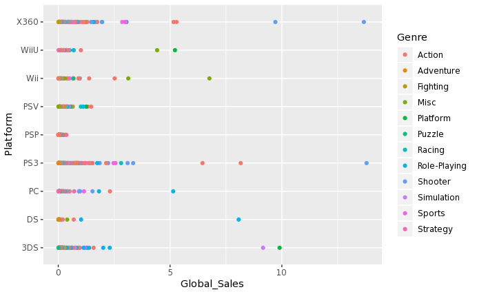

```r
year2012<-
  GameData%>%
  filter(Year_of_Release == 2012)
year2012%>%
  ggplot(aes(x=Global_Sales, y = Platform))+geom_point(aes(color=Genre))
```

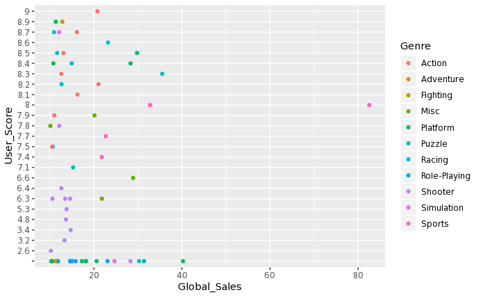

```r
SalesWinners<-
  GameData%>%
  filter(Global_Sales>=10)
SalesWinners%>%
  ggplot(aes(x=Global_Sales, y = User_Score))+geom_point(aes(color=Genre))
```

### Preliminary observations & intution

From above statistics and plots, here are some of my observations:

- Action & Role-playing Genre tends to receive higher User_score.
- Action is the most popular genre according to the quantity.
- North America & Eurpean Union have a evenly distributed genre of games in different platforms.
- Japan has more sales on Role-playing vedio games.
- In the year of 2012, X360 and PS3 are the most popular plotform, and shooter games won the competition.
- For video games with high sales, Action & Racing genre tends to score higher, and shooter games tends to score lower.